# 8. Imputacja szeregów czasowych

# 1 Wczytanie potrzebnych pakietów

```r
library(lubridate)   ## praca z datami
library(dplyr)       ## left_join, mutate
library(ggplot2)
library(imputeTS)    ## wizualizacja i imputacja braków w szeregach
library(tsibble)     ## tidy szeregi czasowe (Hyndman, Wang)
library(forecast)    ## STL + interpolacja sezonowa (Hyndman)
```

# 2 Dane

Zbiór `data8-szereg-czasowy.csv` to symulowana dzienna sprzedaż od 1 lipca do 31 grudnia 2024 (6 miesięcy). Ma dwa typy braków:

- **brakujące daty** – niektóre wiersze zostały usunięte z CSV (cały dzień zniknął),
- **brakujące wartości** – w innych wierszach `sprzedaz = NA`.

Taki podział pozwala oddzielnie pokazać dwa zadania: uzupełnienie kalendarza i imputację wartości.

```r
df <- read.csv("../../data/data8-szereg-czasowy.csv")
df$date <- ymd(df$date)
head(df)
```

```
        date sprzedaz
1 2024-07-01      105
2 2024-07-02      101
3 2024-07-03      107
4 2024-07-04      111
5 2024-07-05      104
6 2024-07-06      125
```

```r
nrow(df)         ## liczba wierszy w CSV
```

```
[1] 172
```

```r
sum(is.na(df$sprzedaz))  ## liczba NA w kolumnie sprzedaz
```

```
[1] 15
```

# 3 Pipeline A: `lubridate` + `imputeTS`

## 3.1 A1. Wykrywanie brakujących dat (`lubridate`)

Tworzymy pełen kalendarz i porównujemy go z datami w pliku.

```r
pelny_kalendarz <- seq.Date(min(df$date), max(df$date), by = "day")
length(pelny_kalendarz)            ## ile dni powinno być
```

```
[1] 184
```

```r
brakujace_daty <- as.Date(setdiff(pelny_kalendarz, df$date),
                          origin = "1970-01-01")
brakujace_daty
```

```
 [1] "2024-07-21" "2024-07-22" "2024-08-09" "2024-08-29" "2024-08-30"
 [6] "2024-08-31" "2024-09-23" "2024-09-28" "2024-09-29" "2024-10-27"
[11] "2024-12-16" "2024-12-19"
```

Dosztukowujemy brakujące daty do ramki przez `left_join` z pełnym kalendarzem i dodajemy informację o dniu tygodnia.

```r
df_pelny <- data.frame(date = pelny_kalendarz) |>
  left_join(df, by = "date") |>
  mutate(dzien_tyg = wday(date, label = TRUE, week_start = 1, abbr = TRUE),
         weekend   = dzien_tyg %in% c("So", "N"))
head(df_pelny)
```

```
        date sprzedaz dzien_tyg weekend
1 2024-07-01      105       Mon   FALSE
2 2024-07-02      101       Tue   FALSE
3 2024-07-03      107       Wed   FALSE
4 2024-07-04      111       Thu   FALSE
5 2024-07-05      104       Fri   FALSE
6 2024-07-06      125       Sat   FALSE
```

```r
nrow(df_pelny)
```

```
[1] 184
```

```r
sum(is.na(df_pelny$sprzedaz))  ## NA = dawne NA + nowo dodane wiersze
```

```
[1] 27
```

## 3.2 A2. Wizualizacja braków (`imputeTS`)

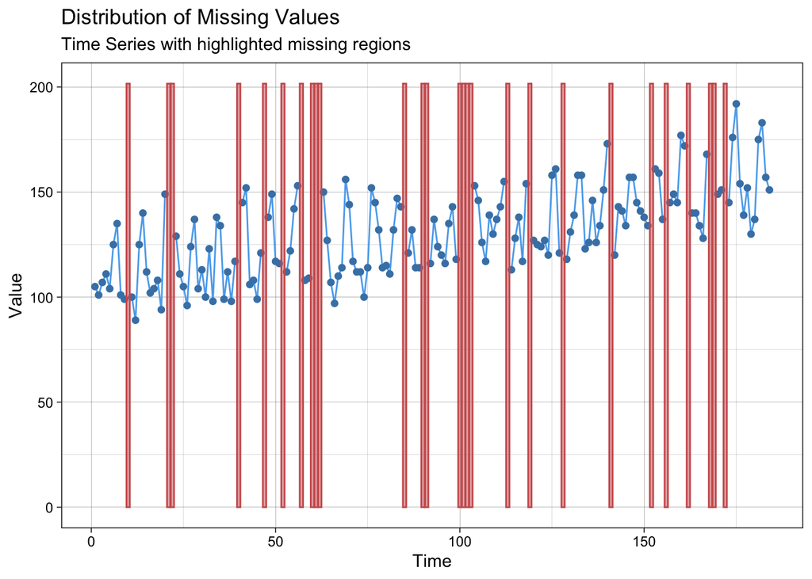

```r
ggplot_na_distribution(df_pelny$sprzedaz)
```

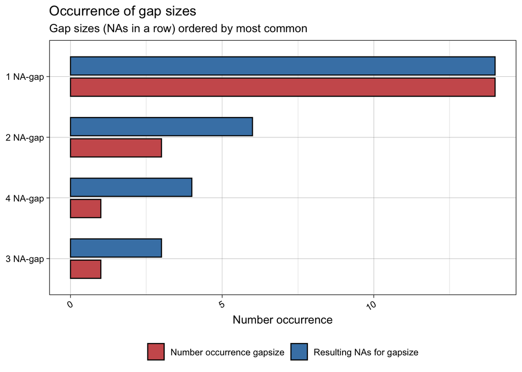

```r
ggplot_na_gapsize(df_pelny$sprzedaz)
```

```r
statsNA(df_pelny$sprzedaz)
```

```
[1] "Length of time series:"
[1] 184
[1] "-------------------------"
[1] "Number of Missing Values:"
[1] 27
[1] "-------------------------"
[1] "Percentage of Missing Values:"
[1] "14.7%"
[1] "-------------------------"
[1] "Number of Gaps:"
[1] 19
[1] "-------------------------"
[1] "Average Gap Size:"
[1] 1.421053
[1] "-------------------------"
```

[output cut: 20 more lines]

## 3.3 A3. Imputacja kilkoma metodami (`imputeTS`)

```r
y <- df_pelny$sprzedaz
y_locf   <- na_locf(y)
y_lin    <- na_interpolation(y, option = "linear")
y_spline <- na_interpolation(y, option = "spline")
y_ma     <- na_ma(y, k = 3, weighting = "exponential")

## UWAGA: dla na_kalman trzeba podać obiekt `ts` z `frequency = 7`,
## żeby StructTS wybrał model BSM (poziom + trend + sezonowość tygodniowa).
## Wywołanie `na_kalman(y, ...)` na zwykłym wektorze daje płaską imputację:
## StructTS dopasowuje wtedy lokalny model poziomu (bez sezonu), więc weekendowe
## szczyty są ignorowane i NA są wypełniane bieżącym poziomem (sprawia wrażenie
## "regresji liniowej"). Porównujemy oba warianty:
y_kalman_naiwny <- na_kalman(y, model = "StructTS")                        ## bez sezonu
y_kalman        <- as.numeric(na_kalman(ts(y, frequency = 7), "StructTS")) ## z sezonem
```

Porównanie wybranej metody (średnia ruchoma) z oryginalnym szeregiem:

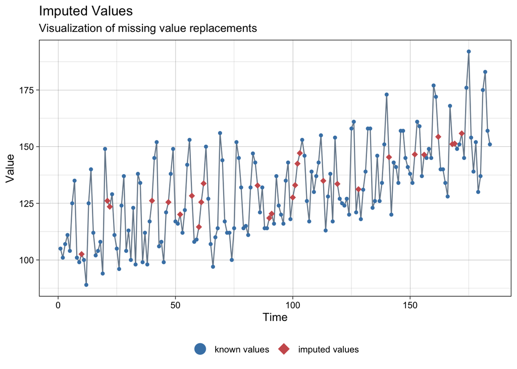

```r
ggplot_na_imputations(y, y_ma)
```

Zbiorcze porównanie wszystkich metod:

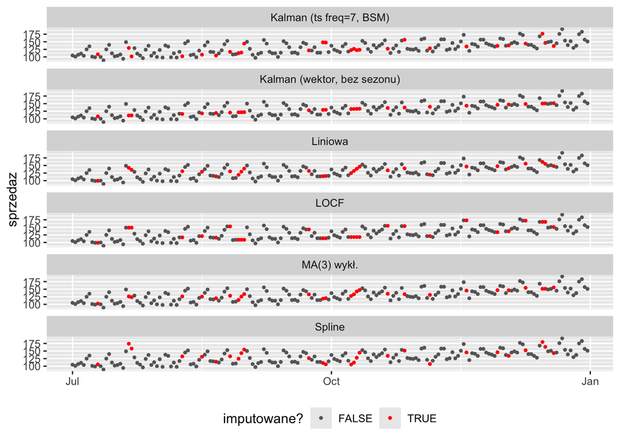

```r
df_porownanie <- data.frame(
  date   = rep(df_pelny$date, 6),
  metoda = rep(c("LOCF", "Liniowa", "Spline", "MA(3) wykł.",
                 "Kalman (wektor, bez sezonu)", "Kalman (ts freq=7, BSM)"),
               each = nrow(df_pelny)),
  wart   = c(y_locf, y_lin, y_spline, y_ma, y_kalman_naiwny, y_kalman),
  imputowane = rep(is.na(y), 6)
)

ggplot(df_porownanie, aes(x = date, y = wart, colour = imputowane)) +
  geom_point(size = 0.8) +
  facet_wrap(~ metoda, ncol = 1) +
  scale_colour_manual(values = c("grey40", "red")) +
  theme(legend.position = "bottom") +
  labs(x = NULL, y = "sprzedaz", colour = "imputowane?")
```

# 4 Pipeline B: `tsibble::fill_gaps()` + `forecast::na.interp()`

Ten sam pomysł, mniej kodu. `tsibble` ma wbudowane wykrywanie luk w indeksie czasowym, a `forecast::na.interp` interpoluje wartości uwzględniając sezonowość (STL).

## 4.1 B1. Wykrywanie luk (`tsibble`)

```r
ts_df <- as_tsibble(df, index = date)
has_gaps(ts_df)
```

```
# A tibble: 1 × 1
  .gaps
  <lgl>
1 TRUE
```

```r
count_gaps(ts_df)
```

```
# A tibble: 8 × 3
  .from      .to           .n
  <date>     <date>     <int>
1 2024-07-21 2024-07-22     2
2 2024-08-09 2024-08-09     1
3 2024-08-29 2024-08-31     3
4 2024-09-23 2024-09-23     1
5 2024-09-28 2024-09-29     2
6 2024-10-27 2024-10-27     1
7 2024-12-16 2024-12-16     1
8 2024-12-19 2024-12-19     1
```

```r
ts_pelny <- ts_df |>
  fill_gaps()           ## dodaje brakujące daty, sprzedaz = NA
nrow(ts_pelny)
```

```
[1] 184
```

```r
sum(is.na(ts_pelny$sprzedaz))
```

```
[1] 27
```

## 4.2 B2. Interpolacja sezonowa (`forecast::na.interp`)

`na.interp` rozkłada szereg STL-em (z `frequency = 7` dla tygodniowej sezonowości) i interpoluje braki z uwzględnieniem tego rozkładu.

```r
y_ts     <- ts(ts_pelny$sprzedaz, frequency = 7)
y_interp <- as.numeric(na.interp(y_ts))
```

## 4.3 B3. Porównanie pipeline’ów

Zestawiamy wynik `forecast::na.interp` z imputacją Kalmana z `imputeTS`.

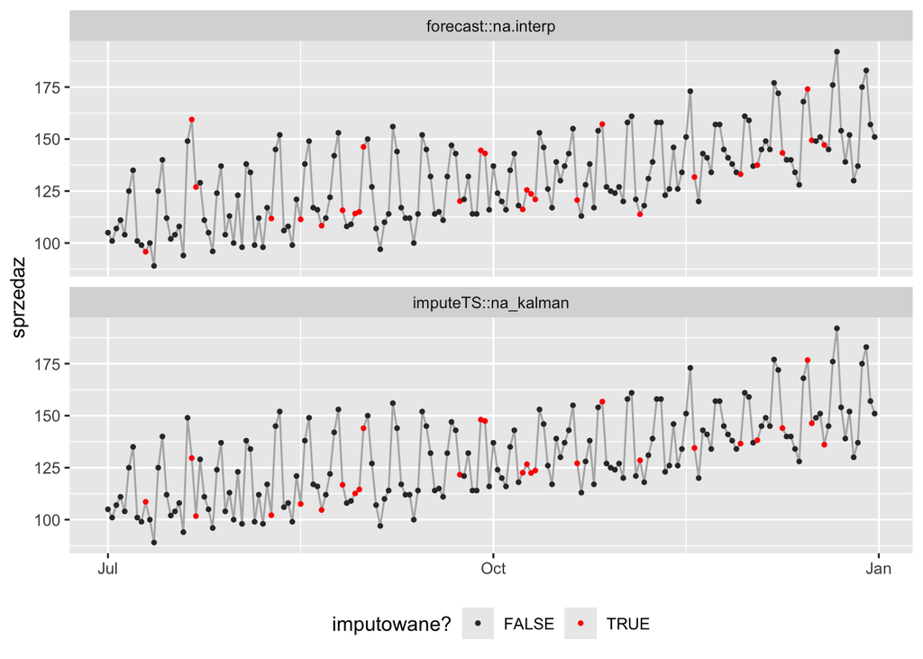

```r
df_AB <- data.frame(
  date   = rep(df_pelny$date, 2),
  metoda = rep(c("imputeTS::na_kalman", "forecast::na.interp"),
               each = nrow(df_pelny)),
  wart   = c(y_kalman, y_interp),
  imputowane = rep(is.na(y), 2)
)

ggplot(df_AB, aes(x = date, y = wart, colour = imputowane)) +
  geom_line(aes(group = metoda), colour = "grey70") +
  geom_point(size = 0.8) +
  facet_wrap(~ metoda, ncol = 1) +
  scale_colour_manual(values = c("grey20", "red")) +
  theme(legend.position = "bottom") +
  labs(x = NULL, y = "sprzedaz", colour = "imputowane?")
```

# 5 Inne pakiety warte uwagi

Pakiety wyspecjalizowane pod imputację w szeregach czasowych i danych podłużnych:

- `padr` – tidy uzupełnianie kalendarza (`pad()`), alternatywa dla `tsibble::fill_gaps`.
- `DTSg` – szybkie operacje na szeregach oparte na `data.table`, z opisem i imputacją braków.
- `zoo`, `xts` – klasyczne klasy szeregów; `na.locf`, `na.approx`, `na.spline`.
- `DTWBI`, `DTWUMI` – imputacja przez Dynamic Time Warping (długie luki, podobne wzorce w przeszłości).
- `tsrobprep` – imputacja przez odporną dekompozycję szeregu.
- `brokenstick` – nieregularne szeregi podłużne, brakujące losowo (MAR).
- `swgee` – IPW dla danych podłużnych z brakami.
- `cold` – modele licznikowe dla danych podłużnych z brakami.
- `prophet`, `stlplus` – modele prognostyczne, które „znoszą” pewne NA przy estymacji.

Wybór narzędzia zależy od długości luk, sezonowości i tego, czy braki dotyczą indeksu czasowego, wartości, czy obu naraz.